# Variance Components, Heritability & Genetic Parameters

- Show All Code
- Hide All Code
- View Source

Analysis 4 of the PUE hybrid series — REML-BLUP mixed models: variance components, G×E, gene action (AV, DV, H², h², BR) and superior-hybrid selection

Author

Fausto Rodriguez Zapata

Published

July 6, 2026

**Paper series — notebook 4.** Shared data preparation: `R/prep_traits.R`.

# 1 Methods (for the paper)

For each of the 11 phenotypes we fit the line × tester mixed model across the five environments with `sommer::mmer` (REML), with environment fixed and combining-ability terms, their environment interactions, and the field-design terms random:

$$y = \mu + E + (L + T + L{:}T) + (L{:}E + T{:}E + L{:}T{:}E) + (\text{rep} + \text{row} + \text{col})_{(E)} + \varepsilon,$$

where $L$ = female line GCA, $T$ = male tester GCA, $L{:}T$ = SCA. From the REML variance components we derive gene action and heritability (definitions below), and from the BLUPs we rank hybrids by genotypic value for the priority traits.

**Genetic parameters (listed in every table).** With $e=5$ environments, $r=3$ reps:

- $\sigma^2_{GCA} = \sigma^2_L + \sigma^2_T$ (additive/GCA), $\sigma^2_{SCA}=\sigma^2_{L:T}$ (non-additive)
- **AV** = additive variance $= 2(\sigma^2_L+\sigma^2_T)$; **DV** = dominance variance $= 4\,\sigma^2_{SCA}$ (individual-plot scale)
- $\sigma^2_G=\sigma^2_L+\sigma^2_T+\sigma^2_{SCA}$; $\sigma^2_{GE}=\sigma^2_{L:E}+\sigma^2_{T:E}+\sigma^2_{L:T:E}$; $\bar V_P=\sigma^2_G+\sigma^2_{GE}/e+\sigma^2_\varepsilon/(er)$
- **H²** (broad, entry-mean) $=\sigma^2_G/\bar V_P$; **h²** (narrow, entry-mean) $=(\sigma^2_L+\sigma^2_T)/\bar V_P$
- **BR — Baker’s ratio** (predictability ratio; Baker 1978) $=\dfrac{2(\sigma^2_L+\sigma^2_T)}{2(\sigma^2_L+\sigma^2_T)+\sigma^2_{SCA}}$. The proportion of among-cross genetic variance that is **additive (GCA)**: **BR → 1** means hybrid performance is predictable from the parents’ general combining ability (additive control), while **BR → 0** means specific combining ability / dominance predominates and performance depends on the particular cross.

AV/DV are individual-scale gene-action estimates; H²/h² are entry-mean (selection) heritabilities — the two scales are reported side by side but not mixed.

*Reference — Baker RJ (1978) Issues in diallel analysis. Crop Science 18:533–536. https://doi.org/10.2135/cropsci1978.0011183X001800040001x*

```r
library(sommer)       # load first so dplyr::select (loaded after) is not masked
library(tidyverse)
library(knitr)
library(kableExtra)

source("R/prep_traits.R")

e_env <- n_distinct(hybrids$env)   # 5
r_rep <- 3
```

# 2 Variance components and genetic parameters

```r
fit_one <- function(tn, d) {
  d <- d %>% mutate(y = .data[[tn]]) %>% filter(!is.na(y))
  fit <- suppressMessages(suppressWarnings(mmer(
    y ~ env,
    random = ~ female + male + cross + female:env + male:env + cross:env +
               env:rep + env:rep:row + env:rep:col,
    data = d, verbose = FALSE)))
  vc <- summary(fit)$varcomp
  # clamp variance components at their 0 boundary (REML can return slight negatives
  # for terms with near-zero genetic variance, e.g. RSR).
  g  <- function(k) { v <- vc$VarComp[sub("\\.y-y$","",rownames(vc)) == k]; if (length(v)) max(0, v) else 0 }
  sL <- g("female"); sT <- g("male"); sS <- g("cross")
  sLE <- g("female:env"); sTE <- g("male:env"); sSE <- g("cross:env"); sE <- g("units")
  sG  <- sL + sT + sS
  sGE <- sLE + sTE + sSE
  Vp  <- sG + sGE / e_env + sE / (e_env * r_rep)
  tibble(trait = tn,
         s2_L = sL, s2_T = sT, s2_SCA = sS, s2_GE = sGE, s2_res = sE,
         AV = 2 * (sL + sT), DV = 4 * sS,
         H2 = sG / Vp, h2 = (sL + sT) / Vp,
         BR = if (2*(sL+sT) + sS > 0) 2*(sL+sT) / (2*(sL+sT) + sS) else NA_real_)
}

vc_res <- map_dfr(analysis_traits, fit_one, d = hybrids) %>%
  left_join(trait_meta, by = "trait") %>% arrange(trait)
```

```r
vc_res %>%
  transmute(Group = group, Trait = trait,
            `σ²_GCA(L)` = round(s2_L, 4), `σ²_GCA(T)` = round(s2_T, 4),
            `σ²_SCA` = round(s2_SCA, 4), `σ²_G×E` = round(s2_GE, 4),
            `σ²_resid` = round(s2_res, 3)) %>%
  kable(caption = "REML variance components per trait (line × tester across 5 environments). L = female line, T = male tester.") %>%
  kable_styling(bootstrap_options = c("striped","hover","condensed"), full_width = FALSE) %>%
  collapse_rows(columns = 1, valign = "top")
```

REML variance components per trait (line × tester across 5 environments). L = female line, T = male tester.

| Group | Trait | σ²_GCA(L) | σ²_GCA(T) | σ²_SCA | σ²_G×E | σ²_resid |
| --- | --- | --- | --- | --- | --- | --- |
| C – Auxiliary | ASI | 0.0000 | 0.0014 | 0.0180 | 0.0378 | 2.335 |
|  | DTA | 0.3736 | 0.4079 | 0.0383 | 0.4024 | 6.150 |
|  | DTS | 0.2990 | 0.5745 | 0.0269 | 0.4640 | 6.619 |
| A – Selection | GY | 0.0362 | 0.0000 | 0.0807 | 0.1554 | 2.246 |
| B – Physiological | HI | 0.0001 | 0.0000 | 0.0003 | 0.0000 | 0.009 |
| C – Auxiliary | PH | 6.8323 | 2.6660 | 7.3880 | 36.7408 | 264.832 |
| A – Selection | PUE | 36.9939 | 0.0000 | 291.1465 | 1308.8628 | 10691.573 |
| B – Physiological | RSR | 0.0000 | 0.0000 | 0.0000 | 0.0000 | 0.002 |
|  | RW | 2.2010 | 1.1203 | 6.0834 | 0.0000 | 125.194 |
|  | SW | 32.7587 | 73.3649 | 84.6311 | 397.6430 | 3156.895 |
|  | TDM | 63.3067 | 105.7963 | 138.1641 | 380.6275 | 3771.566 |

```r
vc_res %>%
  transmute(Group = group, Trait = trait,
            AV = round(AV, 4), DV = round(DV, 4),
            `H² (broad)` = round(H2, 3), `h² (narrow)` = round(h2, 3),
            `BR (Baker)` = round(BR, 3)) %>%
  kable(caption = "Gene action and heritability per trait. AV = additive variance = 2(σ²GCA_L+σ²GCA_T); DV = dominance variance = 4σ²SCA; H² = broad-sense (entry-mean); h² = narrow-sense (entry-mean); BR = Baker's ratio (→1 additive/predictable).") %>%
  kable_styling(bootstrap_options = c("striped","hover","condensed"), full_width = FALSE) %>%
  collapse_rows(columns = 1, valign = "top")
```

Gene action and heritability per trait. AV = additive variance = 2(σ²GCA_L+σ²GCA_T); DV = dominance variance = 4σ²SCA; H² = broad-sense (entry-mean); h² = narrow-sense (entry-mean); BR = Baker's ratio (→1 additive/predictable).

| Group | Trait | AV | DV | H² (broad) | h² (narrow) | BR (Baker) |
| --- | --- | --- | --- | --- | --- | --- |
| C – Auxiliary | ASI | 0.0029 | 0.0718 | 0.106 | 0.008 | 0.138 |
|  | DTA | 1.5630 | 0.1531 | 0.626 | 0.596 | 0.976 |
|  | DTS | 1.7471 | 0.1076 | 0.628 | 0.609 | 0.985 |
| A – Selection | GY | 0.0724 | 0.3228 | 0.393 | 0.122 | 0.473 |
| B – Physiological | HI | 0.0002 | 0.0011 | 0.379 | 0.085 | 0.365 |
| C – Auxiliary | PH | 18.9965 | 29.5521 | 0.403 | 0.227 | 0.720 |
| A – Selection | PUE | 73.9877 | 1164.5860 | 0.252 | 0.028 | 0.203 |
| B – Physiological | RSR | 0.0000 | 0.0000 | 0.056 | 0.056 | 1.000 |
|  | RW | 6.6425 | 24.3335 | 0.530 | 0.187 | 0.522 |
|  | SW | 212.2471 | 338.5242 | 0.397 | 0.221 | 0.715 |
|  | TDM | 338.2059 | 552.6562 | 0.484 | 0.266 | 0.710 |

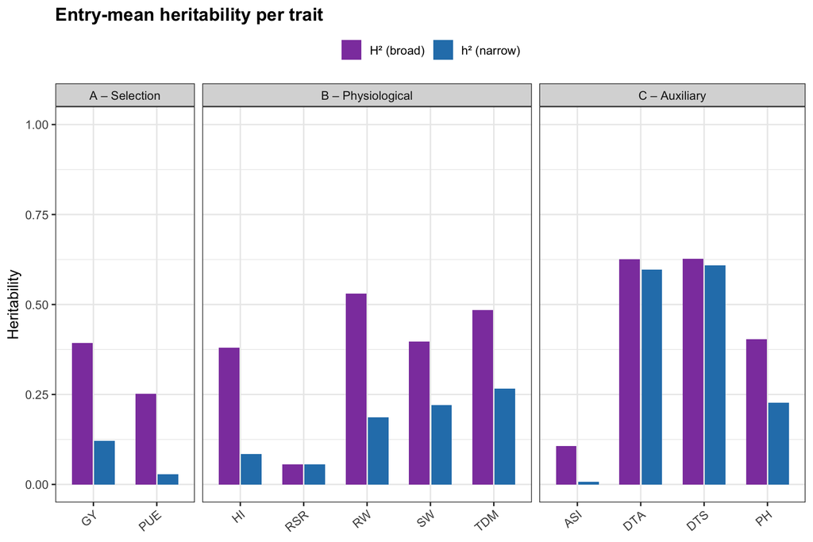

```r
vc_res %>%
  select(trait, group, `h² (narrow)` = h2, `H² (broad)` = H2) %>%
  pivot_longer(c(`h² (narrow)`, `H² (broad)`), names_to = "kind", values_to = "value") %>%
  ggplot(aes(x = trait, y = value, fill = kind)) +
  geom_col(position = position_dodge(width = 0.7), width = 0.65) +
  facet_grid(~ group, scales = "free_x", space = "free_x") +
  scale_fill_manual(values = c("h² (narrow)" = "#2980b9", "H² (broad)" = "#8e44ad"), name = NULL) +
  coord_cartesian(ylim = c(0, 1)) +
  labs(title = "Entry-mean heritability per trait", x = NULL, y = "Heritability") +
  theme_bw(base_size = 12) +
  theme(plot.title = element_text(face = "bold"), legend.position = "top",
        axis.text.x = element_text(angle = 40, hjust = 1))
```

# 3 Superior hybrids by genotypic value (BLUP)

For the priority traits we rank hybrids by **genotypic value** GV = GCA_L(BLUP) + GCA_T(BLUP) + SCA(BLUP) from the REML fit.

```r
top_hybrids <- function(tn, d, n = 8) {
  d <- d %>% mutate(y = .data[[tn]]) %>% filter(!is.na(y))
  fit <- suppressMessages(suppressWarnings(mmer(
    y ~ env,
    random = ~ female + male + cross + female:env + male:env + cross:env +
               env:rep + env:rep:row + env:rep:col,
    data = d, verbose = FALSE)))
  fb <- fit$U$female$y; mb <- fit$U$male$y; cb <- fit$U$cross$y
  key <- d %>% distinct(cross, female, male) %>% mutate(cross = as.character(cross))
  key %>%
    mutate(GCA_L = fb[paste0("female", female)],
           GCA_T = mb[paste0("male", male)],
           SCA   = cb[paste0("cross", cross)],
           GV    = GCA_L + GCA_T + SCA) %>%
    arrange(desc(GV)) %>% head(n) %>%
    transmute(Trait = tn, Hybrid = paste0(female, " × ", male),
              GCA_L = round(GCA_L,3), GCA_T = round(GCA_T,3),
              SCA = round(SCA,3), GV = round(GV,3))
}

top_gv <- map_dfr(c("GY", "PUE"), top_hybrids, d = hybrids)

kable(top_gv, caption = "Top 8 hybrids for the priority traits by genotypic value (GV = GCA_L + GCA_T + SCA, BLUP).") %>%
  kable_styling(bootstrap_options = c("striped","hover","condensed"), full_width = FALSE) %>%
  collapse_rows(columns = 1, valign = "top")
```

Top 8 hybrids for the priority traits by genotypic value (GV = GCA_L + GCA_T + SCA, BLUP).

| Trait | Hybrid | GCA_L | GCA_T | SCA | GV |
| --- | --- | --- | --- | --- | --- |
| GY | CML530 × EN64 | 0.214 | 0 | 0.496 | 0.710 |
|  | CML530 × EN32 | 0.214 | 0 | 0.122 | 0.337 |
|  | CML532 × EN32 | -0.035 | 0 | 0.321 | 0.286 |
|  | CML530 × EN25 | 0.214 | 0 | 0.069 | 0.283 |
|  | CML434 × EN20 | 0.100 | 0 | 0.164 | 0.264 |
|  | CML530 × EN21 | 0.214 | 0 | 0.018 | 0.232 |
|  | CML530 × EN17 | 0.214 | 0 | -0.005 | 0.209 |
|  | CML530 × EN31 | 0.214 | 0 | -0.017 | 0.197 |
| PUE | CML530 × EN64 | 3.622 | 0 | 16.717 | 20.340 |
|  | CML532 × EN32 | 0.168 | 0 | 17.954 | 18.122 |
|  | CML530 × EN25 | 3.622 | 0 | 14.258 | 17.880 |
|  | CML434 × EN20 | 0.736 | 0 | 12.342 | 13.078 |
|  | CML364 × EN21 | -0.728 | 0 | 11.698 | 10.970 |
|  | CML530 × EN32 | 3.622 | 0 | 7.263 | 10.885 |
|  | CML366 × EN17 | -0.586 | 0 | 10.510 | 9.924 |
|  | CML439 × EN31 | -1.649 | 0 | 9.394 | 7.745 |

# 4 Summary

- **Where the additive (GCA) signal is:** read AV and h² — highest for maturity (DTA, DTS) and the traits with female-line differentiation; **GY and PUE have low h²** (male tester GCA ≈ 0), so direct selection on across-environment yield/PUE is weak.
- **Baker’s ratio (BR)** near 1 flags additively-controlled, predictable traits (parental GCA predicts hybrid performance); low BR flags dominance/SCA-driven traits.
- **Superior hybrids** for GY and PUE are ranked by BLUP genotypic value above — the selection output feeding the paper’s recommendation.
- Because yield/PUE are weakly heritable directly, notebook 5 asks whether the more heritable traits (maturity, biomass) **correlate** with PUE, enabling indirect selection.